# 2017 Kaggle Machine Learning & Data Science Survey 1

참고 및 출처 URL:

- [Data Science FAQ | Kaggle](https://www.kaggle.com/rounakbanik/data-science-faq)
- [Novice to Grandmaster | Kaggle](https://www.kaggle.com/ash316/novice-to-grandmaster)
- [박조은 강사님 Github](https://github.com/corazzon/KaggleStruggle/blob/master/kaggle-survey-2017/Kaggle-ML-DS-survey-2017-EDA-FAQ.ipynb)

이 설문조사의 결과를 바탕으로 데이터사이언스와 머신러닝과 관련 된 인사이트를 얻어볼 수 있지 않을까 가설을 세워본다.

# 캐글러를 대상으로 한 설문조사

- 설문기간 : 2017년 8월 7일부터 8월 25일까지
- 평균 응답 시간은 16.4 분
- 171 개 국가 및 지역에서 16,716 명의 응답자
- 특정 국가 또는 지역에서 응답자가 50 명 미만인 경우 익명을 위해 그룹을 '기타'그룹으로 그룹화
- 설문 조사 시스템에 신고 된 응답자를 스팸으로 분류하거나 취업 상태에 관한 질문에 답변하지 않은 응답자는 제외(이 질문은 첫 번째 필수 질문이기에 응답하지 않으면 응답자가 다섯 번째 질문 이후 진행되지 않음)
- 대부분의 응답자는 이메일 목록, 토론 포럼 및 소셜 미디어 Kaggle 채널을 통해 설문을 알게 됨
- 급여데이터는 일부 통화에 대해서만 받고 해당 되는 통화에 기준하여 작성하도록 함
- 미국 달러로 급여를 계산할 수 있도록 USD로 환산 한 csv를 제공
- 질문은 선택적
- 모든 질문이 모든 응답자에게 보여지는 것은 아님
- 취업을 한 사람과 학생을 나누어 다른 질문을 함
- 응답자의 신원을 보호하기 위해 주관식과 객관식 파일로 분리
- 객관식과 자유 형식 응답을 맞추기 위한 키를 제공하지 않음
- 주관식 응답은 같은 행에 나타나는 응답이 반드시 동일한 설문 조사자가 제공하지 않도록 열 단위로 무작위 지정

# 데이터 파일

5 개의 데이터 파일을 제공

- schema.csv : 설문 스키마가있는 CSV 파일입니다. 이 스키마에는 multipleChoiceResponses.csv 및 freeformResponses.csv의 각 열 이름에 해당하는 질문이 포함되어 있습니다.
- multipleChoiceResponses.csv : 객관식 및 순위 질문에 대한 응답자의 답변, 각 행이 한 응답자의 응답
- freeformResponses.csv : Kaggle의 설문 조사 질문에 대한 응답자의 주관식 답변입니다. 임의로 지정되어 각 행이 같은 응답자를 나타내지 않음
- conversionRates.csv : R 패키지 "quantmod"에서 2017 년 9 월 14 일에 액세스 한 통화 변환율 (USD)
- RespondentTypeREADME.txt : schema.csv 파일의 "Asked"열에 응답을 디코딩하는 스키마입니다.

```python
# 노트북 안에서 그래프를 그리기 위해
%matplotlib  inline

#import the standard Python Scientific Libraries
import pandas as pd
import numpy as np
from scipy import stats
import matplotlib.pyplot as plt
import seaborn as sns

#Suppress Deprecation and Incorrect Usage Warnings
import warnings
warnings.filterwarnings('ignore')
```

```python
question = pd.read_csv('schema.csv')
question.shape
```

```
(290, 3)
```

```python
question.head()
```

|  | Column | Question | Asked |
| --- | --- | --- | --- |
| 0 | GenderSelect | Select your gender identity. - Selected Choice | All |
| 1 | GenderFreeForm | Select your gender identity. - A different ide... | All |
| 2 | Country | Select the country you currently live in. | All |
| 3 | Age | What's your age? | All |
| 4 | EmploymentStatus | What's your current employment status? | All |

```python
#판다스로 선다형 객관식 문제에 대한 응답을 가져 옴
mcq = pd.read_csv('multipleChoiceResponses.csv', encoding="ISO-8859-1", low_memory=False)
mcq.shape
```

```
(16716, 228)
```

```python
mcq.head(10)
```

|  | GenderSelect | Country | Age | EmploymentStatus | StudentStatus | LearningDataScience | CodeWriter | CareerSwitcher | CurrentJobTitleSelect | TitleFit | ... | JobFactorExperienceLevel | JobFactorDepartment | JobFactorTitle | JobFactorCompanyFunding | JobFactorImpact | JobFactorRemote | JobFactorIndustry | JobFactorLeaderReputation | JobFactorDiversity | JobFactorPublishingOpportunity |
| --- | --- | --- | --- | --- | --- | --- | --- | --- | --- | --- | --- | --- | --- | --- | --- | --- | --- | --- | --- | --- | --- |
| 0 | Non-binary, genderqueer, or gender non-conforming | NaN | NaN | Employed full-time | NaN | NaN | Yes | NaN | DBA/Database Engineer | Fine | ... | NaN | NaN | NaN | NaN | NaN | NaN | NaN | NaN | NaN | NaN |
| 1 | Female | United States | 30.0 | Not employed, but looking for work | NaN | NaN | NaN | NaN | NaN | NaN | ... | NaN | NaN | NaN | NaN | NaN | NaN | NaN | Somewhat important | NaN | NaN |
| 2 | Male | Canada | 28.0 | Not employed, but looking for work | NaN | NaN | NaN | NaN | NaN | NaN | ... | Very Important | Very Important | Very Important | Very Important | Very Important | Very Important | Very Important | Very Important | Very Important | Very Important |
| 3 | Male | United States | 56.0 | Independent contractor, freelancer, or self-em... | NaN | NaN | Yes | NaN | Operations Research Practitioner | Poorly | ... | NaN | NaN | NaN | NaN | NaN | NaN | NaN | NaN | NaN | NaN |
| 4 | Male | Taiwan | 38.0 | Employed full-time | NaN | NaN | Yes | NaN | Computer Scientist | Fine | ... | NaN | NaN | NaN | NaN | NaN | NaN | NaN | NaN | NaN | NaN |
| 5 | Male | Brazil | 46.0 | Employed full-time | NaN | NaN | Yes | NaN | Data Scientist | Fine | ... | NaN | NaN | NaN | NaN | NaN | NaN | NaN | NaN | NaN | NaN |
| 6 | Male | United States | 35.0 | Employed full-time | NaN | NaN | Yes | NaN | Computer Scientist | Fine | ... | NaN | NaN | NaN | NaN | NaN | NaN | NaN | NaN | NaN | NaN |
| 7 | Female | India | 22.0 | Employed full-time | NaN | NaN | No | Yes | Software Developer/Software Engineer | Fine | ... | Very Important | Somewhat important | Very Important | Somewhat important | Somewhat important | Not important | Very Important | Very Important | Somewhat important | Somewhat important |
| 8 | Female | Australia | 43.0 | Employed full-time | NaN | NaN | Yes | NaN | Business Analyst | Fine | ... | NaN | NaN | NaN | NaN | NaN | NaN | NaN | NaN | NaN | NaN |
| 9 | Male | Russia | 33.0 | Employed full-time | NaN | NaN | Yes | NaN | Software Developer/Software Engineer | Fine | ... | NaN | NaN | NaN | NaN | NaN | NaN | NaN | NaN | NaN | NaN |

10 rows × 228 columns

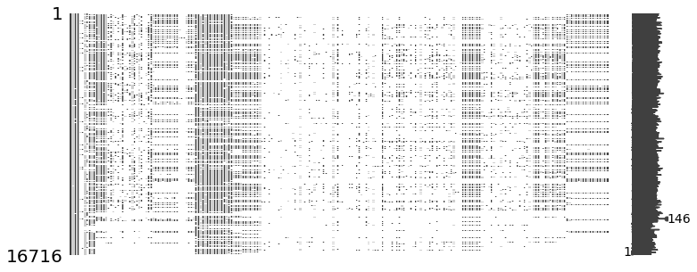

```python
# missingno는 NaN 데이터들에 대해 시각화를 해준다.
# NaN 데이터의 컬럼이 많아 아래 그래프만으로는 내용을 파악하기 어렵다.
import missingno as msno

msno.matrix(mcq, figsize=(12,5))
```

- 16,716 명의 데이터와 228개의 선다형 객관식문제와 62개의 주관식 질문에 대한 응답이다. (총 290개의 질문) 응답하지 않은 질문이 많음

# 설문통계

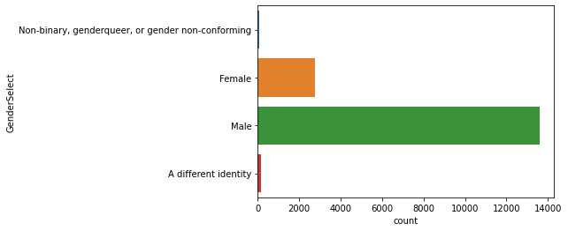

```python
#성별
sns.countplot(y='GenderSelect', data=mcq)
```

여성보다는 남성의 비율이 훨씬 높은 편이다.

```python
#국가별 응답수
con_df = pd.DataFrame(mcq['Country'].value_counts())
#print(con_df)
#'country'컬럼을 인덱스로 지정해 주고
con_df['국가']=con_df.index
#컬럼의 순서대로 응답 수, 국가로 컬럼명을 지정해 줌
con_df.colums = ['응답 수', '국가']
#index 컬럼을 삭제하고 순위를 알기위해 reset_index()를 해줌
#우리 나라는 18위, 전체 52개국에서 참여했지만 20위까지만 본다.
con_df=con_df.reset_index().drop('index', axis=1)
con_df.head(20)
```

|  | Country | 국가 |
| --- | --- | --- |
| 0 | 4197 | United States |
| 1 | 2704 | India |
| 2 | 1023 | Other |
| 3 | 578 | Russia |
| 4 | 535 | United Kingdom |
| 5 | 471 | People 's Republic of China |
| 6 | 465 | Brazil |
| 7 | 460 | Germany |
| 8 | 442 | France |
| 9 | 440 | Canada |
| 10 | 421 | Australia |
| 11 | 320 | Spain |
| 12 | 277 | Japan |
| 13 | 254 | Taiwan |
| 14 | 238 | Italy |
| 15 | 205 | Netherlands |
| 16 | 196 | Ukraine |
| 17 | 194 | South Korea |
| 18 | 184 | Singapore |
| 19 | 184 | Poland |

```python
# 연령에 대한 정보를 본다.
mcq['Age'].describe()
```

```
count    16385.000000
mean        32.372841
std         10.473487
min          0.000000
25%         25.000000
50%         30.000000
75%         37.000000
max        100.000000
Name: Age, dtype: float64
```

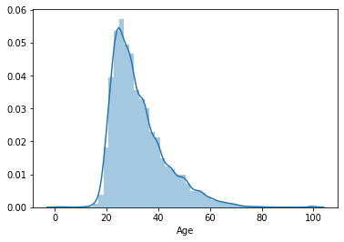

```python
sns.distplot(mcq[mcq['Age']>0]['Age'])
```

# 학력

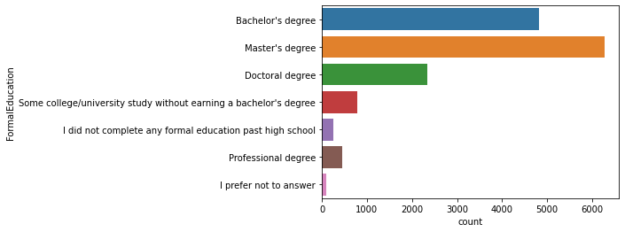

```python
sns.countplot(y='FormalEducation', data=mcq)
```

학사 학위를 가진 사람보다 석사 학위를 가지고 있는 사람이 많으며, 박사학위를 가지고 있는 사람들도 많다.

```python
pd.DataFrame(mcq['MajorSelect'].value_counts())
```

|  | MajorSelect |
| --- | --- |
| Computer Science | 4397 |
| Mathematics or statistics | 2220 |
| Engineering (non-computer focused) | 1339 |
| Electrical Engineering | 1303 |
| Other | 848 |
| Physics | 830 |
| Information technology, networking, or system administration | 693 |
| A social science | 531 |
| Biology | 274 |
| Management information systems | 237 |
| A humanities discipline | 198 |
| A health science | 152 |
| Psychology | 137 |
| I never declared a major | 65 |
| Fine arts or performing arts | 57 |

# 전공

```python
# value_counts 를 사용하면 그룹화 된 데이터의 카운트 값을 보여준다.
# normalize=True 옵션을 사용하면,
# 해당 데이터가 전체 데이터에서 어느정도의 비율을 차지하는지 알 수 있다.
mcq_major_count = pd.DataFrame(mcq['MajorSelect'].value_counts())
mcq_major_percent = pd.DataFrame(mcq['MajorSelect'].value_counts(normalize=True))
mcq_major_df = mcq_major_count.merge(mcq_major_percent, left_index=True, right_index=True)
mcq_major_df.columns = ['응답 수', '비율']
mcq_major_df
```

|  | 응답 수 | 비율 |
| --- | --- | --- |
| Computer Science | 4397 | 0.331074 |
| Mathematics or statistics | 2220 | 0.167156 |
| Engineering (non-computer focused) | 1339 | 0.100821 |
| Electrical Engineering | 1303 | 0.098110 |
| Other | 848 | 0.063851 |
| Physics | 830 | 0.062495 |
| Information technology, networking, or system administration | 693 | 0.052180 |
| A social science | 531 | 0.039982 |
| Biology | 274 | 0.020631 |
| Management information systems | 237 | 0.017845 |
| A humanities discipline | 198 | 0.014909 |
| A health science | 152 | 0.011445 |
| Psychology | 137 | 0.010315 |
| I never declared a major | 65 | 0.004894 |
| Fine arts or performing arts | 57 | 0.004292 |

컴퓨터 전공자들이 33%로 가장 많으며, 다음으로 수학, 공학, 전기 공학 순이다.

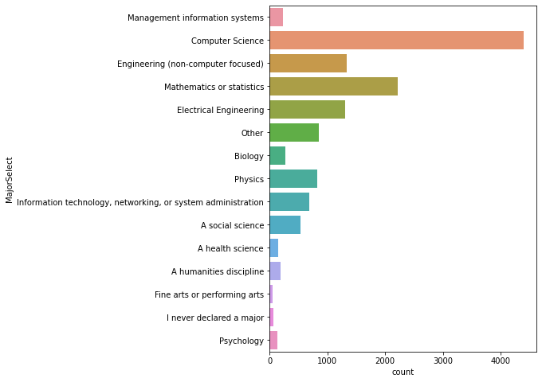

```python
#사람들의 전공 현황
plt.figure(figsize=(6,8))
sns.countplot(y='MajorSelect', data = mcq)
```

# 취업 여부

```python
mcq_es_count = pd.DataFrame(mcq['EmploymentStatus'].value_counts())
mcq_es_percent = pd.DataFrame(mcq['EmploymentStatus'].value_counts(normalize=True))
mcq_es_df = mcq_es_count.merge(mcq_es_percent, left_index=True, right_index=True)
mcq_es_df.columns = ['응답 수', '비율']
mcq_es_df
```

|  | 응답 수 | 비율 |
| --- | --- | --- |
| Employed full-time | 10897 | 0.651890 |
| Not employed, but looking for work | 2110 | 0.126226 |
| Independent contractor, freelancer, or self-employed | 1330 | 0.079564 |
| Not employed, and not looking for work | 924 | 0.055276 |
| Employed part-time | 917 | 0.054858 |
| I prefer not to say | 420 | 0.025126 |
| Retired | 118 | 0.007059 |

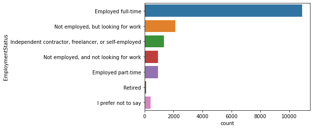

```python
sns.countplot(y='EmploymentStatus', data=mcq)
```

응답자의 대부분이 65%가 풀타임으로 일하고 있으며, 그 다음으로 구직자가 12%다.

# 프로그래밍 경험

- 'Tenure'항목은 데이터사이언스 분야에서 코딩 경험이 얼마나 되는지에 대한 질문이다. 대부분이 5년 미만이며, 특히 1~2년의 경험을 가진 사람들이 많다.

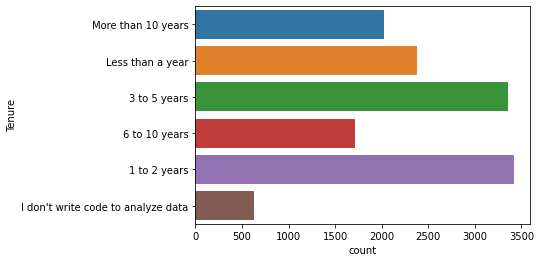

```python
sns.countplot(y='Tenure', data=mcq)
```

```
The number of interviewees in Korea: 194
```

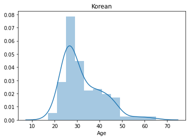

```python
korea = mcq.loc[(mcq['Country']=='South Korea')]

print('The number of interviewees in Korea: ' + str(korea.shape[0]))

sns.distplot(korea['Age'].dropna())
plt.title('Korean')
plt.show()
```

```python
pd.DataFrame(korea['GenderSelect'].value_counts())
```

|  | GenderSelect |
| --- | --- |
| Male | 156 |
| Female | 37 |
| A different identity | 1 |

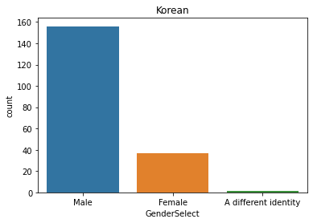

```python
sns.countplot(x='GenderSelect', data=korea)
plt.title('Korean')
```

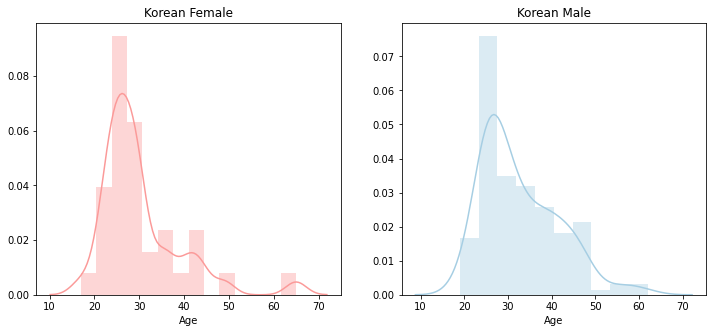

```python
figure, (ax1, ax2) = plt.subplots(ncols=2)
figure.set_size_inches(12,5)

sns.distplot( korea['Age'].loc[korea['GenderSelect']=='Female'].dropna(),
             norm_hist=False, color=sns.color_palette("Paired")[4], ax=ax1)
ax1.set_title('Korean Female')

sns.distplot(korea['Age'].loc[korea['GenderSelect']=='Male'].dropna(),
             norm_hist=False, color=sns.color_palette("Paired")[0], ax=ax2)
ax2.set_title('Korean Male')
```

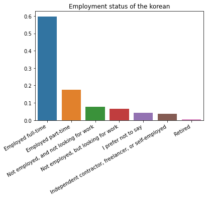

```python
sns.barplot(x=korea['EmploymentStatus'].unique(),y=korea['EmploymentStatus'].value_counts()/len(korea))
plt.xticks(rotation=30, ha='right')
plt.title('Employment status of the korean')
plt.ylabel('')
plt.show()
```

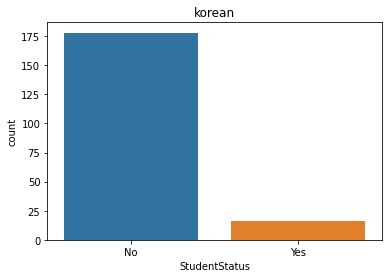

```python
korea['StudentStatus'] = korea['StudentStatus'].fillna('No')
sns.countplot(x='StudentStatus', data=korea)
plt.title('korean')
plt.show()
```

```python
full_time = mcq.loc[(mcq['EmploymentStatus'] == 'Employed full-time')]
print(full_time.shape)
looking_for_job = mcq.loc[(
    mcq['EmploymentStatus'] == 'Not employed, but looking for work')]
print(looking_for_job.shape)
```

```
(10897, 228)
(2110, 228)
```

# 자주 묻는 질문 FAQ

- 초보자들이 묻는 가장 일반적인 질문에 대한 답을 시각화 해본다.

## Q1. Python과 R중 어떤 언어를 배워야 할까요?

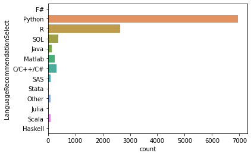

```python
sns.countplot(y='LanguageRecommendationSelect', data=mcq)
```

파이썬을 명확하게 선호하고 있는 것으로 보여지며, 전문가와 강사들이 선호하는 언어를 알아본다.

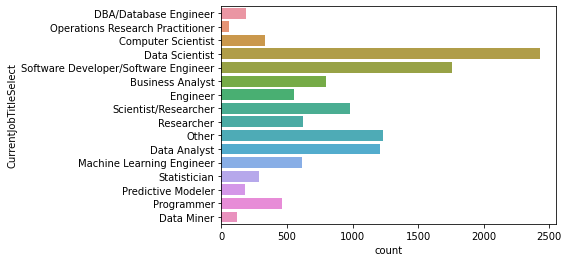

```python
# 현재 하고 있는 일
sns.countplot(y=mcq['CurrentJobTitleSelect'])
```

```python
# 현재 하고 있는 일에 대한 전체 응답수
mcq[mcq['CurrentJobTitleSelect'].notnull()]['CurrentJobTitleSelect'].shape
```

```
(11830,)
```

```
(7158, 228)
```

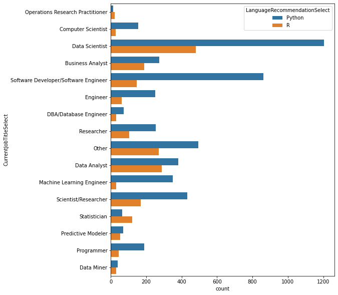

```python
# 현재 하고 있는 일에 대한 응답을 해준 사람 중 Python과 R을 사용하는 사람
# 응답자들이 실제 업무에서 어떤 언어를 주로 사용하는지 볼 수 있다.
data = mcq[(mcq['CurrentJobTitleSelect'].notnull()) & (
    (mcq['LanguageRecommendationSelect'] == 'Python') | (
        mcq['LanguageRecommendationSelect'] == 'R'))]
print(data.shape)
plt.figure(figsize=(8, 10))
sns.countplot(y='CurrentJobTitleSelect',
              hue='LanguageRecommendationSelect',
              data=data)
```

## Q2. 데이터 사이언스 분야에서 앞으로 크게 주목받을 것은 무엇일까요?

- 관련 분야의 종사자가 아니더라도 빅데이터, 딥러닝, 뉴럴네트워크 같은 용어에 대해 알고 있다. 응답자들이 내년에 가장 흥미로운 기술이 될 것이라 응답한 것이다.

### 데이터사이언스 툴

```python
mcq_ml_tool_count = pd.DataFrame(
    mcq['MLToolNextYearSelect'].value_counts())
mcq_ml_tool_percent = pd.DataFrame(
    mcq['MLToolNextYearSelect'].value_counts(normalize=True))

mcq_ml_tool_df = mcq_ml_tool_count.merge(
    mcq_ml_tool_percent, left_index=True, right_index=True).head(20)
mcq_ml_tool_df.columns = ['응답 수', '비율']
mcq_ml_tool_df
```

|  | 응답 수 | 비율 |
| --- | --- | --- |
| TensorFlow | 2621 | 0.238316 |
| Python | 1713 | 0.155756 |
| R | 910 | 0.082742 |
| Spark / MLlib | 755 | 0.068649 |
| Hadoop/Hive/Pig | 417 | 0.037916 |
| Other | 407 | 0.037007 |
| Amazon Machine Learning | 392 | 0.035643 |
| Jupyter notebooks | 358 | 0.032551 |
| I don't plan on learning a new tool/technology | 341 | 0.031006 |
| Google Cloud Compute | 296 | 0.026914 |
| Amazon Web services | 273 | 0.024823 |
| Julia | 222 | 0.020185 |
| Microsoft Azure Machine Learning | 220 | 0.020004 |
| DataRobot | 220 | 0.020004 |
| IBM Watson / Waton Analytics | 194 | 0.017640 |
| C/C++ | 186 | 0.016912 |
| Tableau | 150 | 0.013639 |
| SQL | 138 | 0.012548 |
| Java | 116 | 0.010547 |
| MATLAB/Octave | 115 | 0.010456 |

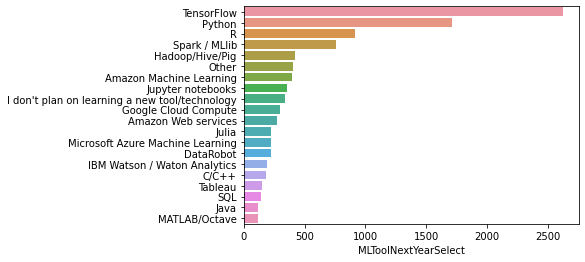

```python
data = mcq['MLToolNextYearSelect'].value_counts().head(20)
sns.barplot(y=data.index, x=data)
```

### 다음 해에 주목할 만한 Data Science Methods

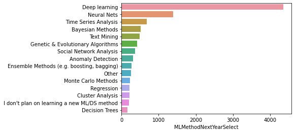

```python
data = mcq['MLMethodNextYearSelect'].value_counts().head(15)
sns.barplot(y=data.index, x=data)
```

응답에 대한 통계를 보면 딥러닝과 뉴럴넷이 엄청나게 인기가 있을 것이고 시계열 분석, 베이지안, 텍스트 마이닝 등의 내용이 있다. 중간 쯤에 부스팅과 배깅 같은 앙상블 메소드도 있다.

## Q3. 어디에서 데이터 사이언스를 배워야 할까요?

```python
mcq['LearningPlatformSelect']
```

```
0        College/University,Conferences,Podcasts,Trade ...
1                                                   Kaggle
2        Arxiv,College/University,Kaggle,Online courses...
3        Blogs,College/University,Conferences,Friends n...
4                        Arxiv,Conferences,Kaggle,Textbook
                               ...
16711                                                  NaN
16712    Kaggle,Non-Kaggle online communities,Online co...
16713                                                  NaN
16714                                                  NaN
16715                                                  NaN
Name: LearningPlatformSelect, Length: 16716, dtype: object
```

```python
# 한 줄로 되어있는 여러개의 응답을 각각의 원소로 나눠서 리스트에 저장함
# 즉 Kaggle, Online courses -> [Kaggle, Online courses]

# 1. mcq의 컬럼 LearningPlatformSelect에 존재하는 값을 string값으로 바꿔줌
#   string 값으로 바꿔주는 이유 : 뒤에 나오는 lambda가 split(',')를 수행하는데 이때 string인 경우에만 사용가능하기 때문이다.
#   NaN의 경우 이 때 데이터 타입은 float 로 인식 되기 때문에 astype('str')을 해주는 것임

mcq['LearningPlatformSelect'] = mcq['LearningPlatformSelect'].astype('str').apply(lambda x: x.split(','))
mcq['LearningPlatformSelect']
```

```
0        [College/University, Conferences, Podcasts, Tr...
1                                                 [Kaggle]
2        [Arxiv, College/University, Kaggle, Online cou...
3        [Blogs, College/University, Conferences, Frien...
4                   [Arxiv, Conferences, Kaggle, Textbook]
                               ...
16711                                                [nan]
16712    [Kaggle, Non-Kaggle online communities, Online...
16713                                                [nan]
16714                                                [nan]
16715                                                [nan]
Name: LearningPlatformSelect, Length: 16716, dtype: object
```

```python
# 리스트의 원소 값을 분리해서 한 행에 하나의 데이터만 들어가도록 처리함
# 즉 [ Kaggle, Online courses] -> [Kaggle]
#                              -> [Online courses]

# 1-1. mcq의 LearningPlatformSelect컬럼 중, axis가 1인 즉, 열의 값을 선택해서 내부의 데이터를 Series 데이터 구조로 바꾼다.
#      mcq.apply(lambda x: pd.Series(x['LearningPlatformSelect']), axis=1)

s = mcq.apply(
    lambda x: pd.Series(x['LearningPlatformSelect']),
    axis=1)
print(s)
```

```
                        0                              1               2  \
0      College/University                    Conferences        Podcasts
1                  Kaggle                            NaN             NaN
2                   Arxiv             College/University          Kaggle
3                   Blogs             College/University     Conferences
4                   Arxiv                    Conferences          Kaggle
...                   ...                            ...             ...
16711                 nan                            NaN             NaN
16712              Kaggle  Non-Kaggle online communities  Online courses
16713                 nan                            NaN             NaN
16714                 nan                            NaN             NaN
16715                 nan                            NaN             NaN

                        3                       4               5  \
0              Trade book                     NaN             NaN
```

[output cut: 38 more lines]

```python
# 1-2. 리스트로 표횐된 자료를 .stack()을 이용해 2level 데이터 프레임으로 바꿔줌
#                 (2level 이란 인덱스 2개사용해 2차원 배열 구조를 시각화 한 것)
#      .stack() 메서드 사용하면 0번 인덱스에 저장되어있던 값이 세부항목을 리스트가 아닌 리스트에 달려있던 인덱스 넘버로 출력됨
s = mcq.apply(
    lambda x: pd.Series(x['LearningPlatformSelect']),
    axis=1).stack()
s.head(10)
```

```
0  0    College/University
   1           Conferences
   2              Podcasts
   3            Trade book
1  0                Kaggle
2  0                 Arxiv
   1    College/University
   2                Kaggle
   3        Online courses
   4        YouTube Videos
dtype: object
```

```python
# 1-3. 2level 인덱스 중, 하나를 없애서 보기 편하게 바꿈
#     .stack()까지 2레벨의 데이터 프레임 인덱스 중, level=1 의 인덱스를 drop함
#      즉, 위에서 0 1 2 3 0 0... 로 진행되는 인덱스 drop시킴
#      참고) 맨 앞의 0     12  처럼 표현되는 인덱스 level은 0 임

s = mcq.apply(
    lambda x: pd.Series(x['LearningPlatformSelect']),
    axis=1).stack().reset_index(level=1, drop=True)
# <class 'pandas.core.series.Series'> 인 s에 컬럼 이름을 platform이라고 명명해줌
s.name = 'platform'
s.head(10)
```

```
0    College/University
0           Conferences
0              Podcasts
0            Trade book
1                Kaggle
2                 Arxiv
2    College/University
2                Kaggle
2        Online courses
2        YouTube Videos
Name: platform, dtype: object
```

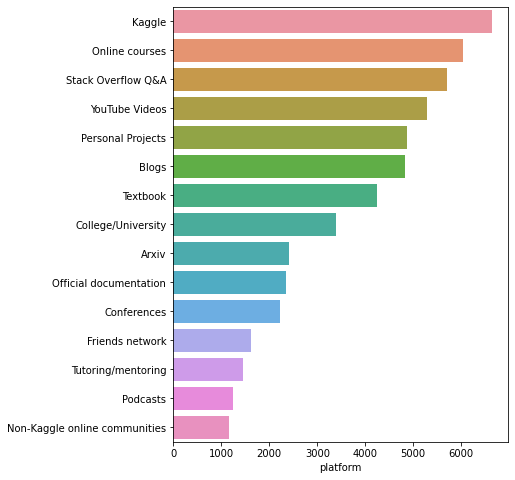

```python
# 출력 될 figure 크기 설정 .figsize(가로, 세로)
plt.figure(figsize=(6,8))

# s에서 s가 nan인 값을 제외하고 각 원소가 몇개 있는지 갯수를 셈
# 그 후 상위 15개 선택함
data = s[s != 'nan'].value_counts().head(15)
sns.barplot(y=data.index, x=data)
```

- Kaggle은 우리 응답자들 사이에서 가장 인기있는 학습 플랫폼
- 그러나 이 설문 조사를 실시한 곳이 Kaggle이기 때문에 응답이 편향되었을 수 있음
- 온라인 코스, 스택 오버플로 및 유튜브 (YouTube) 상위 5 대 최우수 학습 플랫폼은 대학 학위나 교과서의 중요도보다 높다.

```python
# 설문내용과 누구에게 물어봤는지를 찾아봄

# question은 schema.csv를 담고 있는 데이터 프레임
# question의 Column이라는 명칭을 가진 컬럼에서 LearningCategory라는 글자가 들어간 컬럼만 선택해서 컬럼의 명칭과 데이터를 qc에 담는다.
qc = question.loc[question['Column'].str.contains('LearningCategory')]
print(qc.shape)
qc
```

```
(7, 3)
```

|  | Column | Question | Asked |
| --- | --- | --- | --- |
| 91 | LearningCategorySelftTaught | What percentage of your current machine learni... | All |
| 92 | LearningCategoryOnlineCourses | What percentage of your current machine learni... | All |
| 93 | LearningCategoryWork | What percentage of your current machine learni... | All |
| 94 | LearningCategoryUniversity | What percentage of your current machine learni... | All |
| 95 | LearningCategoryKaggle | What percentage of your current machine learni... | All |
| 96 | LearningCategoryOther | What percentage of your current machine learni... | All |
| 97 | LearningCategoryOtherFreeForm | What percentage of your current machine learni... | All |

```python
# mcq의 컬럼중 LearningPlatformUsefulness가 들어간 것들을 찾아서 use_features 리스트에 넣음

use_features = [x for x in mcq.columns if x.find(
    'LearningPlatformUsefulness') != -1]
```

```python
# 학습플랫폼과 유용함에 대한 연관성을 살펴본다.

# fdf : 데이터를 담을 딕셔너리 타입의 객체 생성
fdf = {}
for feature in use_features:
    a = mcq[feature].value_counts()
    a = a/a.sum()
    # fdf에 LearningPlatformUsefulnessArxiv의 LearningPlatformUsefulness을 뺀 것을 key로, a를 value로 한다.
    fdf[feature[len('LearningPlatformUsefulness'):]] = a
# fdf 데이터 행(Very useful, Somewhat useful, Not Useful), 열(백분율 즉, a값)
print(fdf)
```

```
{'Arxiv': Very useful        0.550397
Somewhat useful    0.434128
Not Useful         0.015475
Name: LearningPlatformUsefulnessArxiv, dtype: float64, 'Blogs': Somewhat useful    0.504932
Very useful        0.485624
Not Useful         0.009444
Name: LearningPlatformUsefulnessBlogs, dtype: float64, 'College': Very useful        0.551652
Somewhat useful    0.418279
Not Useful         0.030068
Name: LearningPlatformUsefulnessCollege, dtype: float64, 'Company': Somewhat useful    0.511723
Very useful        0.446483
Not Useful         0.041794
Name: LearningPlatformUsefulnessCompany, dtype: float64, 'Conferences': Somewhat useful    0.598075
Very useful        0.347388
Not Useful         0.054537
Name: LearningPlatformUsefulnessConferences, dtype: float64, 'Friends': Somewhat useful    0.489564
Very useful        0.478178
Not Useful         0.032258
Name: LearningPlatformUsefulnessFriends, dtype: float64, 'Kaggle': Very useful        0.619171
Somewhat useful    0.372323
Not Useful         0.008507
Name: LearningPlatformUsefulnessKaggle, dtype: float64, 'Newsletters': Somewhat useful    0.629936
Very useful        0.318641
Not Useful         0.051423
Name: LearningPlatformUsefulnessNewsletters, dtype: float64, 'Communities': Somewhat useful    0.496497
Very useful        0.489492
Not Useful         0.014011
Name: LearningPlatformUsefulnessCommunities, dtype: float64, 'Documentation': Very useful        0.522189
Somewhat useful    0.459716
Not Useful         0.018096
Name: LearningPlatformUsefulnessDocumentation, dtype: float64, 'Courses': Very useful        0.700100
Somewhat useful    0.292056
Not Useful         0.007844
Name: LearningPlatformUsefulnessCourses, dtype: float64, 'Projects': Very useful        0.744681
Somewhat useful    0.247184
Not Useful         0.008135
Name: LearningPlatformUsefulnessProjects, dtype: float64, 'Podcasts': Somewhat useful    0.673806
Very useful        0.224053
Not Useful         0.102142
Name: LearningPlatformUsefulnessPodcasts, dtype: float64, 'SO': Very useful        0.626241
Somewhat useful    0.362411
Not Useful         0.011348
Name: LearningPlatformUsefulnessSO, dtype: float64, 'Textbook': Very useful        0.553934
Somewhat useful    0.429562
Not Useful         0.016503
Name: LearningPlatformUsefulnessTextbook, dtype: float64, 'TradeBook': Somewhat useful    0.486486
Very useful        0.486486
Not Useful         0.027027
Name: LearningPlatformUsefulnessTradeBook, dtype: float64, 'Tutoring': Very useful        0.578541
Somewhat useful    0.399018
Not Useful         0.022440
Name: LearningPlatformUsefulnessTutoring, dtype: float64, 'YouTube': Somewhat useful    0.498183
Very useful        0.481928
Not Useful         0.019889
Name: LearningPlatformUsefulnessYouTube, dtype: float64}
```

```python
# Very useful 에 대한 내림차순 정렬 수행
# 내림차순 정렬 위해 fdf의 행과열 위치 바꿔야함 (transpose)

fdf = pd.DataFrame(fdf).transpose().sort_values(
    'Very useful', ascending=False)
```

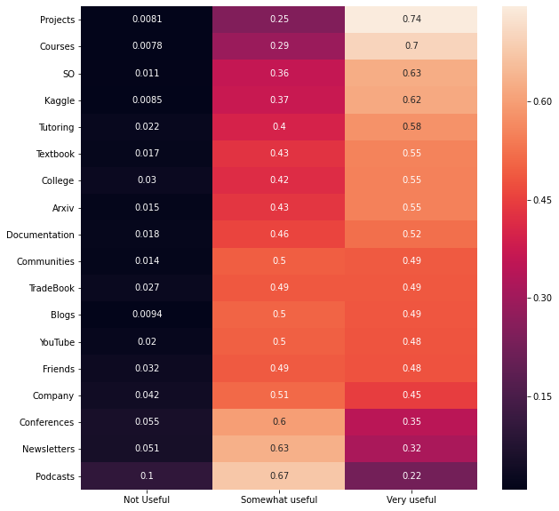

```python
# 학습플랫폼들이 얼마나 유용한지에 대한 상관관계를 그려본다.
# annot=True 이면 각 셀에 데이터 값을 씀, annot 은 annotation(주석)의 약자

plt.figure(figsize=(10,10))
sns.heatmap(
    fdf.sort_values(
        "Very useful", ascending=False), annot=True)
```

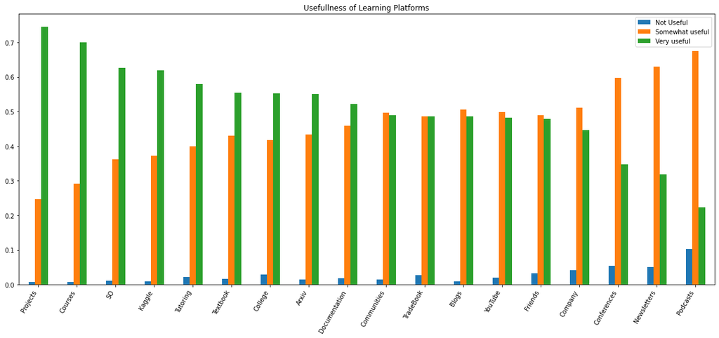

```python
# 유용함의 정도를 각 플랫폼별로 그룹화 해서 본다.
fdf.plot(kind='bar', figsize=(20,8),
         title="Usefullness of Learning Platforms")
plt.xticks(rotation=60, ha='right')
```

```python
cat_features = [x for x in mcq.columns if x.find(
    'LearningCategory') != -1]
cat_features
```

```
['LearningCategorySelftTaught',
 'LearningCategoryOnlineCourses',
 'LearningCategoryWork',
 'LearningCategoryUniversity',
 'LearningCategoryKaggle',
 'LearningCategoryOther']
```

```python
cdf = {}
for feature in cat_features:
    cdf[feature[len('LearningCategory'):]] = mcq[feature].mean()

# 파이차트를 그리기 위해 평균 값을 구해와서 담아준다.
cdf = pd.Series(cdf)
cdf
```

```
SelftTaught      33.366771
OnlineCourses    27.375514
Work             15.217593
University       16.988607
Kaggle            5.531434
Other             1.795940
dtype: float64
```

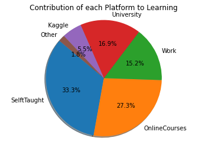

```python
# 학습 플랫폼 별 도움이 되는 정도를 그려본다.
plt.pie(cdf, labels=cdf.index,
        autopct='%1.1f%%', shadow=True, startangle=140)
plt.axis('equal')
plt.title("Contribution of each Platform to Learning")
plt.show()
```

## Q4. 데이터과학을 위해 높은 사양의 컴퓨터가 필요한가요?

```python
# 설문내용과 누구에게 물어봤는지를 찾아봄
qc = question.loc[question[
    'Column'].str.contains('HardwarePersonalProjectsSelect')]
print(qc.shape)
qc
```

```
(1, 3)
```

|  | Column | Question | Asked |
| --- | --- | --- | --- |
| 74 | HardwarePersonalProjectsSelect | Which computing hardware do you use for your p... | Learners |

```python
mcq[mcq['HardwarePersonalProjectsSelect'].notnull()][
    'HardwarePersonalProjectsSelect'].shape
```

```
(4206,)
```

```python
mcq['HardwarePersonalProjectsSelect'
   ] = mcq['HardwarePersonalProjectsSelect'
          ].astype('str').apply(lambda x: x.split(','))
s = mcq.apply(lambda x:
              pd.Series(x['HardwarePersonalProjectsSelect']),
              axis=1).stack().reset_index(level=1, drop=True)
s.name = 'hardware'
```

```python
s = s[s != 'nan']
```

```python
pd.DataFrame(s.value_counts())
```

|  | hardware |
| --- | --- |
| Basic laptop (Macbook) | 2246 |
| Laptop + Cloud service (AWS | 669 |
| Azure | 669 |
| GCE ...) | 669 |
| Gaming Laptop (Laptop + CUDA capable GPU) | 641 |
| Traditional Workstation | 527 |
| Laptop or Workstation and local IT supported servers | 445 |
| GPU accelerated Workstation | 416 |
| Workstation + Cloud service | 174 |
| Other | 147 |

맥북을 사용하는 응답자가 가장많고, 랩탑과 함께 클라우드를 사용하는 사람들이 그 다음이고 적당한 GPU를 가진 게임용 노트북을 사용하는 사례가 그 다음이다.

## Q5. 데이터 사이언스 공부에 얼마나 많은 시간을 사용하는지?

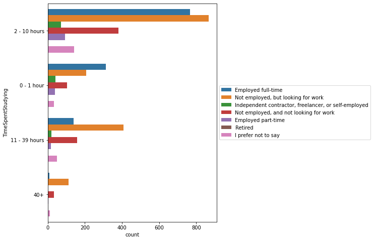

```python
plt.figure(figsize=(6, 8))
sns.countplot(y='TimeSpentStudying',
              data=mcq,
              hue='EmploymentStatus'
             ).legend(loc='center left',
                      bbox_to_anchor=(1, 0.5))
```

풀타임으로 일하는 사람들은 2~10시간 일하는 비율이 높으며, 풀타임으로 일하는 사람보다 일을 찾고 있는 사람들이 더 많은 시간을 공부하는 편이다.

하지만 응답자 중 대부분이 풀타임으로 일하고 있는 사람들이라는 것을 고려할 필요가 있다.

```python
full_time = mcq.loc[(mcq['EmploymentStatus'] == 'Employed full-time')]
print(full_time.shape)
looking_for_job = mcq.loc[(
    mcq['EmploymentStatus'] == 'Not employed, but looking for work')]
print(looking_for_job.shape)
```

```
(10897, 228)
(2110, 228)
```

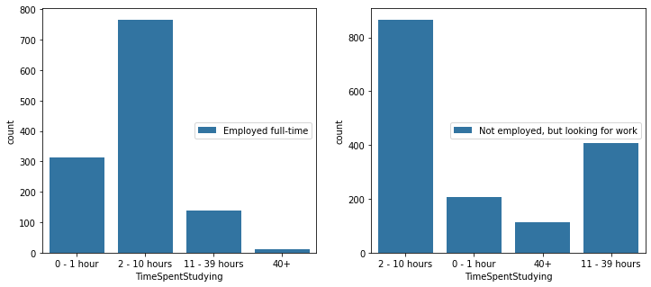

```python
figure, (ax1, ax2) = plt.subplots(ncols=2)

figure.set_size_inches(12,5)
sns.countplot(x='TimeSpentStudying',
              data=full_time,
              hue='EmploymentStatus', ax=ax1
             ).legend(loc='center right',
                      bbox_to_anchor=(1, 0.5))

sns.countplot(x='TimeSpentStudying',
              data=looking_for_job,
              hue='EmploymentStatus', ax=ax2
             ).legend(loc='center right',
                      bbox_to_anchor=(1, 0.5))
```

## Q6. 블로그, 팟캐스트, 수업 기타 등등 추천할만한 것이 있는지?

```python
# 판다스로 선다형 객관식 문제에 대한 응답을 가져 옴
mcq = pd.read_csv('multipleChoiceResponses.csv', encoding="ISO-8859-1", low_memory=False)
mcq.shape
```

```
(16716, 228)
```

```python
mcq['BlogsPodcastsNewslettersSelect'] = mcq[
    'BlogsPodcastsNewslettersSelect'
].astype('str').apply(lambda x: x.split(','))
mcq['BlogsPodcastsNewslettersSelect'].head()
```

```
0    [Becoming a Data Scientist Podcast, Data Machi...
1    [Becoming a Data Scientist Podcast, Siraj Rava...
2    [FastML Blog, No Free Hunch Blog, Talking Mach...
3                                     [KDnuggets Blog]
4    [Data Machina Newsletter, Jack's Import AI New...
Name: BlogsPodcastsNewslettersSelect, dtype: object
```

```python
s = mcq.apply(lambda x: pd.Series(x['BlogsPodcastsNewslettersSelect']),
              axis=1).stack().reset_index(level=1, drop=True)
s.name = 'platforms'
s.head()
```

```
0    Becoming a Data Scientist Podcast
0              Data Machina Newsletter
0             O'Reilly Data Newsletter
0         Partially Derivative Podcast
0           R Bloggers Blog Aggregator
Name: platforms, dtype: object
```

```python
s = s[s != 'nan'].value_counts().head(20)
```

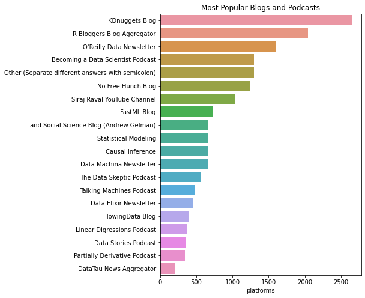

```python
plt.figure(figsize=(6,8))
plt.title("Most Popular Blogs and Podcasts")
sns.barplot(y=s.index, x=s)
```

KDNuggets Blog, R Bloggers Blog Aggregator 그리고 O'Reilly Data Newsletter 가 가장 유용하다고 투표를 받았다. 데이터 사이언스 되기라는 팟캐스트도 유명한 듯 하다.

[Machine Learning, Data Science, Big Data, Analytics](https://www.kdnuggets.com/)

[Becoming a Data Scientist - YouTube - YouTube](https://www.youtube.com/channel/UCfxnrdBM1YRV9j2MB8aiy4Q)

[Siraj Raval - YouTube - YouTube](https://www.youtube.com/channel/UCWN3xxRkmTPmbKwht9FuE5A)

```python
mcq['CoursePlatformSelect'] = mcq[
    'CoursePlatformSelect'].astype(
    'str').apply(lambda x: x.split(','))
mcq['CoursePlatformSelect'].head()
```

```
0              [nan]
1              [nan]
2    [Coursera, edX]
3              [nan]
4              [nan]
Name: CoursePlatformSelect, dtype: object
```

```python
t = mcq.apply(lambda x: pd.Series(x['CoursePlatformSelect']),
              axis=1).stack().reset_index(level=1, drop=True)
t.name = 'courses'
t.head(20)
```

```
0          nan
1          nan
2     Coursera
2          edX
3          nan
4          nan
5          nan
6          nan
7     Coursera
8          nan
9          nan
10    Coursera
11         nan
12    Coursera
12    DataCamp
12         edX
13         nan
14         nan
15         nan
16         nan
Name: courses, dtype: object
```

```python
t = t[t != 'nan'].value_counts()
```

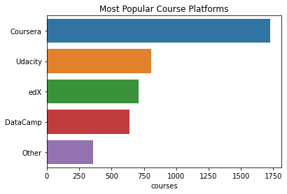

```python
plt.title("Most Popular Course Platforms")
sns.barplot(y=t.index, x=t)
```

Coursera와 Udacity가 가장 인기있는 플랫폼이다.

## Q7. 데이터 사이언스 직무에서 가장 중요하다고 생각되는 스킬은?

```python
job_features = [
    x for x in mcq.columns if x.find(
        'JobSkillImportance') != -1
    and x.find('JobSkillImportanceOther') == -1]

job_features
```

```
['JobSkillImportanceBigData',
 'JobSkillImportanceDegree',
 'JobSkillImportanceStats',
 'JobSkillImportanceEnterpriseTools',
 'JobSkillImportancePython',
 'JobSkillImportanceR',
 'JobSkillImportanceSQL',
 'JobSkillImportanceKaggleRanking',
 'JobSkillImportanceMOOC',
 'JobSkillImportanceVisualizations']
```

```python
jdf = {}
for feature in job_features:
    a = mcq[feature].value_counts()
    a = a/a.sum()
    jdf[feature[len('JobSkillImportance'):]] = a

jdf
```

```
{'BigData': Nice to have    0.574065
 Necessary       0.379929
 Unnecessary     0.046006
 Name: JobSkillImportanceBigData, dtype: float64,
 'Degree': Nice to have    0.598107
 Necessary       0.279867
 Unnecessary     0.122026
 Name: JobSkillImportanceDegree, dtype: float64,
 'Stats': Necessary       0.513889
 Nice to have    0.457576
 Unnecessary     0.028535
 Name: JobSkillImportanceStats, dtype: float64,
 'EnterpriseTools': Nice to have    0.564970
 Unnecessary     0.290200
 Necessary       0.144829
 Name: JobSkillImportanceEnterpriseTools, dtype: float64,
 'Python': Necessary       0.645994
 Nice to have    0.327214
 Unnecessary     0.026792
 Name: JobSkillImportancePython, dtype: float64,
 'R': Nice to have    0.513945
 Necessary       0.414807
 Unnecessary     0.071247
 Name: JobSkillImportanceR, dtype: float64,
 'SQL': Nice to have    0.491778
 Necessary       0.434224
 Unnecessary     0.073998
 Name: JobSkillImportanceSQL, dtype: float64,
 'KaggleRanking': Nice to have    0.677261
 Unnecessary     0.203876
 Necessary       0.118863
 Name: JobSkillImportanceKaggleRanking, dtype: float64,
 'MOOC': Nice to have    0.606994
 Unnecessary     0.285752
 Necessary       0.107255
 Name: JobSkillImportanceMOOC, dtype: float64,
 'Visualizations': Nice to have    0.490820
 Necessary       0.455392
 Unnecessary     0.053788
 Name: JobSkillImportanceVisualizations, dtype: float64}
```

```python
jdf = pd.DataFrame(jdf).transpose()
jdf
```

|  | Necessary | Nice to have | Unnecessary |
| --- | --- | --- | --- |
| BigData | 0.379929 | 0.574065 | 0.046006 |
| Degree | 0.279867 | 0.598107 | 0.122026 |
| Stats | 0.513889 | 0.457576 | 0.028535 |
| EnterpriseTools | 0.144829 | 0.564970 | 0.290200 |
| Python | 0.645994 | 0.327214 | 0.026792 |
| R | 0.414807 | 0.513945 | 0.071247 |
| SQL | 0.434224 | 0.491778 | 0.073998 |
| KaggleRanking | 0.118863 | 0.677261 | 0.203876 |
| MOOC | 0.107255 | 0.606994 | 0.285752 |
| Visualizations | 0.455392 | 0.490820 | 0.053788 |

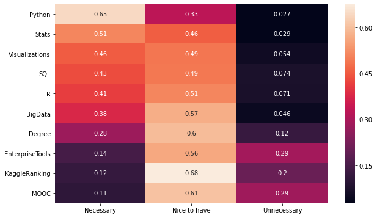

```python
plt.figure(figsize=(10,6))
sns.heatmap(jdf.sort_values("Necessary",
                            ascending=False), annot=True)
```

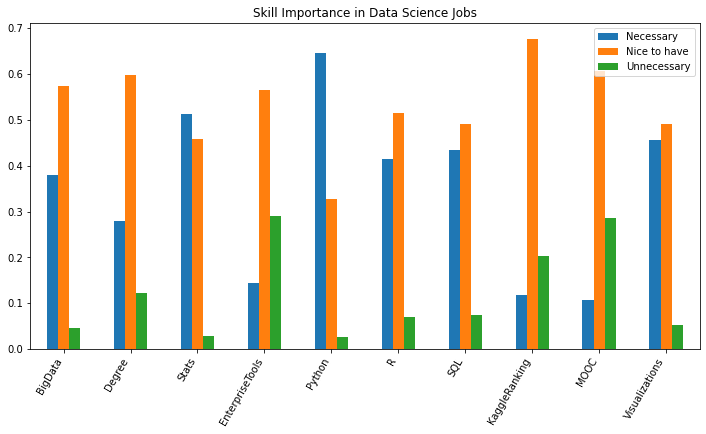

```python
jdf.plot(kind='bar', figsize=(12,6),
         title="Skill Importance in Data Science Jobs")
plt.xticks(rotation=60, ha='right')
```

있으면 좋은 것은 빅데이터, 학위, 툴 사용법, 캐글랭킹, 무크가 있다.

## Q8. 데이터 과학자의 평균 급여는 얼마나 될까?

```python
# 데이터 프레임의 컬럼을 최대 12개로 늘린다.

pd.set_option('display.max_columns', 12)

# schema.csv를 question 객체에 담기

question = pd.read_csv('schema.csv')

# multipleChoiceResponses.csv를 mcq에 담기. encoding='ISO-8859-1'은 범용적으로 사용되는 인코딩이다.

mcq = pd.read_csv('multipleChoiceResponses.csv', encoding='ISO-8859-1', low_memory=False)

# 한국 자료를 따로 설정해준다.

korea = mcq.loc[mcq.Country == 'South Korea']
```

```python
mcq[mcq['CompensationAmount'].notnull()].shape
```

```
(5224, 228)
```

```python
# 자료 내에 존재하는 , or - 를 없앰
mcq['CompensationAmount'] = mcq[
    'CompensationAmount'].str.replace(',','')
mcq['CompensationAmount'] = mcq[
    'CompensationAmount'].str.replace('-','')

# 환율계산을 위한 정보 가져오기
rates = pd.read_csv('conversionRates.csv')
rates.head()
```

|  | Unnamed: 0 | originCountry | exchangeRate |
| --- | --- | --- | --- |
| 0 | 1 | USD | 1.000000 |
| 1 | 2 | EUR | 1.195826 |
| 2 | 3 | INR | 0.015620 |
| 3 | 4 | GBP | 1.324188 |
| 4 | 5 | BRL | 0.321350 |

```python
# Unnamed: 0 지우기 위해 drop 사용
# inplace 초기 값 : False -> drop() 이 rates를 변경시키지 않음
#                   True  -> drop() 이 rates를 변경함. 즉, drop()실행 결과가 rates에 저장
rates.drop('Unnamed: 0',axis=1,inplace=True)
rates.head()
```

|  | originCountry | exchangeRate |
| --- | --- | --- |
| 0 | USD | 1.000000 |
| 1 | EUR | 1.195826 |
| 2 | INR | 0.015620 |
| 3 | GBP | 1.324188 |
| 4 | BRL | 0.321350 |

```python
# 언급한 컬럼만 뽑고 Nan 제거함(dropna())
salary = mcq[
    ['CompensationAmount','CompensationCurrency',
     'GenderSelect',
     'Country',
     'CurrentJobTitleSelect']].dropna()

# 좌측은 CompensationCurrency
# 우측은 originCountry
# salary의 우측에 rates를 병합

salary = salary.merge(rates,left_on='CompensationCurrency',
                      right_on='originCountry', how='left')

print(salary.shape)
salary.head()
```

```
(4367, 7)
```

|  | CompensationAmount | CompensationCurrency | GenderSelect | Country | CurrentJobTitleSelect | originCountry | exchangeRate |
| --- | --- | --- | --- | --- | --- | --- | --- |
| 0 | 250000 | USD | Male | United States | Operations Research Practitioner | USD | 1.000000 |
| 1 | 80000 | AUD | Female | Australia | Business Analyst | AUD | 0.802310 |
| 2 | 1200000 | RUB | Male | Russia | Software Developer/Software Engineer | RUB | 0.017402 |
| 3 | 95000 | INR | Male | India | Data Scientist | INR | 0.015620 |
| 4 | 1100000 | TWD | Male | Taiwan | Software Developer/Software Engineer | TWD | 0.033304 |

```python
# 숫자가 아닌 것을 숫자로 바꿔주는 to_numeric()메서드.
salary['Salary'] = pd.to_numeric(
    salary['CompensationAmount']) * salary['exchangeRate']
salary.head()
```

|  | CompensationAmount | CompensationCurrency | GenderSelect | Country | CurrentJobTitleSelect | originCountry | exchangeRate | Salary |
| --- | --- | --- | --- | --- | --- | --- | --- | --- |
| 0 | 250000 | USD | Male | United States | Operations Research Practitioner | USD | 1.000000 | 250000.0 |
| 1 | 80000 | AUD | Female | Australia | Business Analyst | AUD | 0.802310 | 64184.8 |
| 2 | 1200000 | RUB | Male | Russia | Software Developer/Software Engineer | RUB | 0.017402 | 20882.4 |
| 3 | 95000 | INR | Male | India | Data Scientist | INR | 0.015620 | 1483.9 |
| 4 | 1100000 | TWD | Male | Taiwan | Software Developer/Software Engineer | TWD | 0.033304 | 36634.4 |

```python
print('Maximum Salary is USD $',
      salary['Salary'].dropna().astype(int).max())
print('Minimum Salary is USD $',
      salary['Salary'].dropna().astype(int).min())
print('Median Salary is USD $',
      salary['Salary'].dropna().astype(int).median())
```

```
Maximum Salary is USD $ 208999999
Minimum Salary is USD $ -2147483648
Median Salary is USD $ 53812.0
```

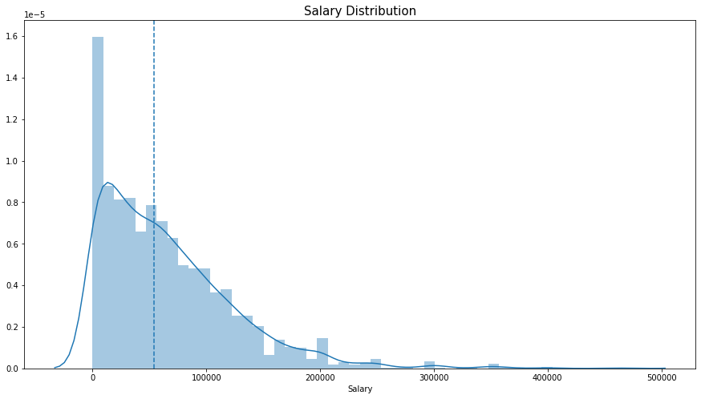

```python
#시각화
plt.subplots(figsize=(15,8))
salary=salary[salary['Salary']<500000]
sns.distplot(salary['Salary'])
#중앙값을 점선으로 표시
plt.axvline(salary['Salary'].median(), linestyle='dashed')
plt.title('Salary Distribution',size=15)
```

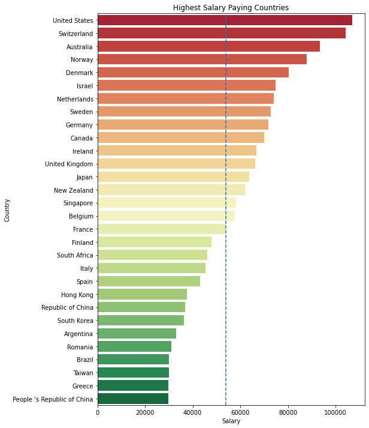

```python
# 나라별 중앙값을 비교하여 어느 나라의 봉급이 더 많은지 확인
plt.subplots(figsize=(8,12))

sal_coun = salary.groupby(
    'Country')['Salary'].median().sort_values(
    ascending=False)[:30].to_frame()

sns.barplot('Salary',
            sal_coun.index,
            data = sal_coun,
            palette='RdYlGn')

plt.axvline(salary['Salary'].median(), linestyle='dashed')
plt.title('Highest Salary Paying Countries')
```

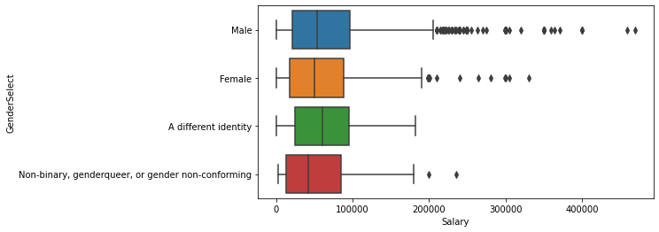

```python
# 전 세계의 남성, 여성의 임금 차이 보여주는 boxplot
plt.subplots(figsize=(8,4))
sns.boxplot(y='GenderSelect',x='Salary', data=salary)
```

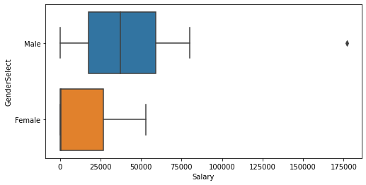

```python
# 한국의 경우 남여 임금 차이를 보여주는 boxplot
salary_korea = salary.loc[(salary['Country']=='South Korea')]
plt.subplots(figsize=(8,4))
sns.boxplot(y='GenderSelect',x='Salary',data=salary_korea)
```

```python
salary_korea.shape
# 총 26명이 응답한 것임
```

```
(26, 8)
```

```python
salary_korea[salary_korea['GenderSelect'] == 'Female']
# 한국의 경우 여성 응답자가 3명, 너무 적은 숫자
```

|  | CompensationAmount | CompensationCurrency | GenderSelect | Country | CurrentJobTitleSelect | originCountry | exchangeRate | Salary |
| --- | --- | --- | --- | --- | --- | --- | --- | --- |
| 479 | 30000 | KRW | Female | South Korea | Data Analyst | KRW | 0.000886 | 26.58 |
| 2903 | 800000 | KRW | Female | South Korea | Researcher | KRW | 0.000886 | 708.80 |
| 4063 | 60000000 | KRW | Female | South Korea | Researcher | KRW | 0.000886 | 53160.00 |

```python
# 남성 봉급에 대한 요약
salary_korea_male = salary_korea[
    salary_korea['GenderSelect']== 'Male']
salary_korea_male['Salary'].describe()
```

```
count        23.000000
mean      43540.617217
std       37800.608484
min           0.886000
25%       17500.000000
50%       37212.000000
75%       59238.000000
max      177200.000000
Name: Salary, dtype: float64
```

```python
salary_korea_male
```

|  | CompensationAmount | CompensationCurrency | GenderSelect | Country | CurrentJobTitleSelect | originCountry | exchangeRate | Salary |
| --- | --- | --- | --- | --- | --- | --- | --- | --- |
| 85 | 40000000 | KRW | Male | South Korea | Business Analyst | KRW | 0.000886 | 35440.000 |
| 147 | 80000 | USD | Male | South Korea | Researcher | USD | 1.000000 | 80000.000 |
| 314 | 60000 | USD | Male | South Korea | Business Analyst | USD | 1.000000 | 60000.000 |
| 333 | 60000000 | KRW | Male | South Korea | Researcher | KRW | 0.000886 | 53160.000 |
| 562 | 50000000 | KRW | Male | South Korea | Researcher | KRW | 0.000886 | 44300.000 |
| 769 | 42000000 | KRW | Male | South Korea | Software Developer/Software Engineer | KRW | 0.000886 | 37212.000 |
| 799 | 1000 | KRW | Male | South Korea | Machine Learning Engineer | KRW | 0.000886 | 0.886 |
| 1060 | 75000000 | KRW | Male | South Korea | Scientist/Researcher | KRW | 0.000886 | 66450.000 |
| 1360 | 30000000 | KRW | Male | South Korea | Statistician | KRW | 0.000886 | 26580.000 |
| 1568 | 90000 | SGD | Male | South Korea | Computer Scientist | SGD | 0.742589 | 66833.010 |
| 1576 | 10800000 | KRW | Male | South Korea | Data Scientist | KRW | 0.000886 | 9568.800 |
| 1905 | 20000 | USD | Male | South Korea | Researcher | USD | 1.000000 | 20000.000 |
| 1945 | 50000 | KRW | Male | South Korea | Machine Learning Engineer | KRW | 0.000886 | 44.300 |
| 1949 | 80000000 | KRW | Male | South Korea | Software Developer/Software Engineer | KRW | 0.000886 | 70880.000 |
| 2322 | 200000000 | KRW | Male | South Korea | Other | KRW | 0.000886 | 177200.000 |
| 2334 | 60000000 | KRW | Male | South Korea | Machine Learning Engineer | KRW | 0.000886 | 53160.000 |
| 2557 | 7200000 | KRW | Male | South Korea | Researcher | KRW | 0.000886 | 6379.200 |
| 2924 | 15000 | USD | Male | South Korea | Researcher | USD | 1.000000 | 15000.000 |
| 3394 | 66000000 | KRW | Male | South Korea | Programmer | KRW | 0.000886 | 58476.000 |
| 3832 | 30000000 | KRW | Male | South Korea | Data Scientist | KRW | 0.000886 | 26580.000 |
| 3979 | 35000000 | KRW | Male | South Korea | Researcher | KRW | 0.000886 | 31010.000 |
| 4300 | 60000000 | KRW | Male | South Korea | Scientist/Researcher | KRW | 0.000886 | 53160.000 |
| 4366 | 10000 | USD | Male | South Korea | Data Scientist | USD | 1.000000 | 10000.000 |